# Ordinal Data

Dr Lauren M Ackerman

02 April 2019

[🔙 Home](https://verbingnouns.github.io/notebooks/)

# What is “ordinal” data?

Data like reaction times is *continuous* because there are no discrete boundaries. RTs can be seconds, fractions of sections, fractions of milliseconds, or even finer grained than that.

Data like counts of words in corpora are *discrete*, but hypothetically infinite. You could have 0 attestations, 1, or one million… but you could not have 13.5 attestations of a word.

*Binary* data is also discrete, and can come from looking at hits vs misses (e.g., correct or incorrect responses) among other things. This data type is binary because there are only two values you can observe: 1 (hit) or 0 (miss).

But there is another type of data we use often, too. *Ordinal* data refers to data that is discrete but also ranked like in a Likert scale task. What makes this type of data unique is that it has a maximum and minimum endpoint, but also a limited number of (ordered) values in between. In this respect, binary data and ordinal data are similar, but when you have more than two possible responses, analysis can get quite complicated.

In particular, what makes analysis of ordinal data different from continuous, count, and binary data is that the perceptual size of each level may vary. That is, on a 7-point scale, the difference between a rating of 1 and a rating of 2 may not be the same distance as the difference between a rating of 2 and a rating of 3, or between a rating of 6 and a rating of 7. The distance between each level of the scale can vary across participants and items, so when we analyse this data, we really should take into account this dimension of variability.

That’s where the `ordinal` package comes in.

```r
library(ordinal)

dataOrd <- read.csv("data/ordinal_data.csv",header=TRUE)
head(dataOrd)
```

```
##   subject item  factor1 factor2 rating
## 1       1    1 Baseline  Absent      5
## 2       1    2 Baseline  Absent      6
## 3       1    3 Baseline  Absent      7
## 4       1    4 Baseline  Absent      7
## 5       1    5 Baseline  Absent      7
## 6       1    6 Baseline  Absent      7
```

When we graph our rating data in a box plot, we see there is likely to be a main effect of *Factor 1* and possibly an interaction between *Factor 1* and *Factor 2*. It’s hard to tell more at this point.

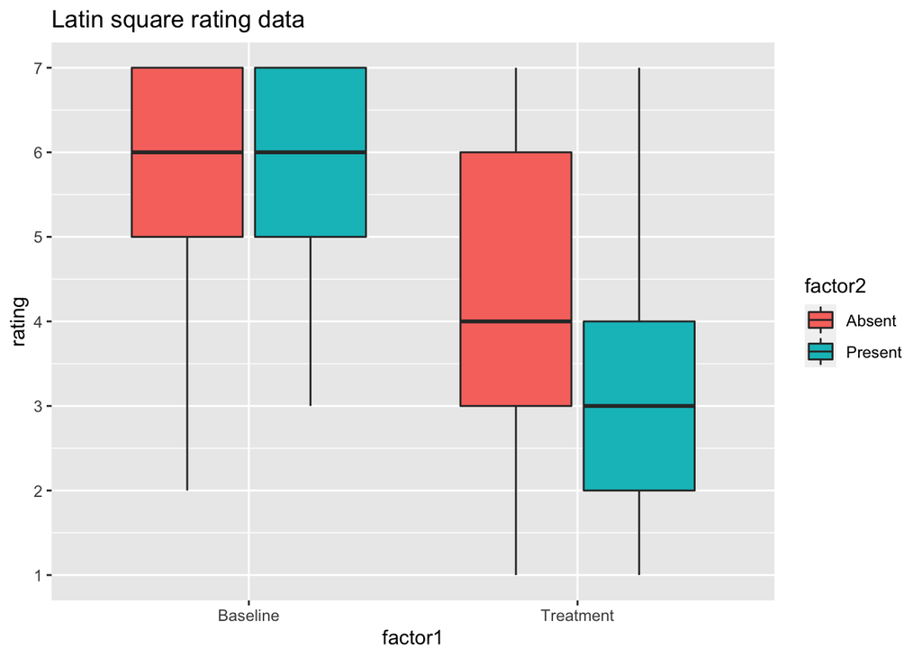

```r
ggplot(dataOrd, aes(x=factor1,y=rating)) + geom_boxplot(aes(fill=factor2)) + scale_y_continuous(breaks=c(1:7)) + ggtitle("Latin square rating data")
```

First, we can look at only the main effect of *Factor 1*. Visually speaking, it looks likely to be significant because the interquartile ranges do not overlap (although this is just a rule of thumb).

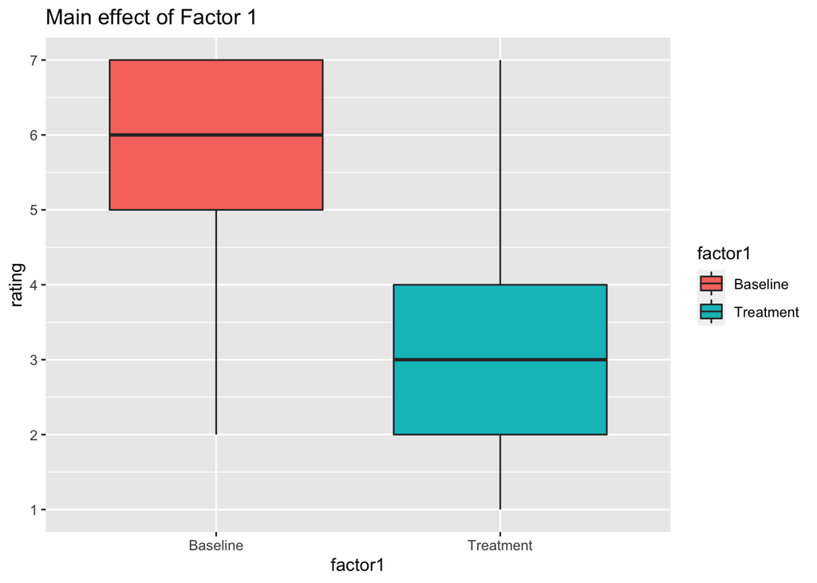

```r
ggplot(dataOrd, aes(x=factor1,y=rating)) + geom_boxplot(aes(fill=factor1)) + scale_y_continuous(breaks=c(1:7)) + ggtitle("Main effect of Factor 1")
```

Turning to *Factor 2*, it’s not clear whether these two levels differ or not. The interquartile ranges largely overlap and the median bars appear to overlap the other group’s interquartile range. Simply put, this suggests the distributions don’t differ very much at this level of granularity. (Still, this is a rule of thumb.)

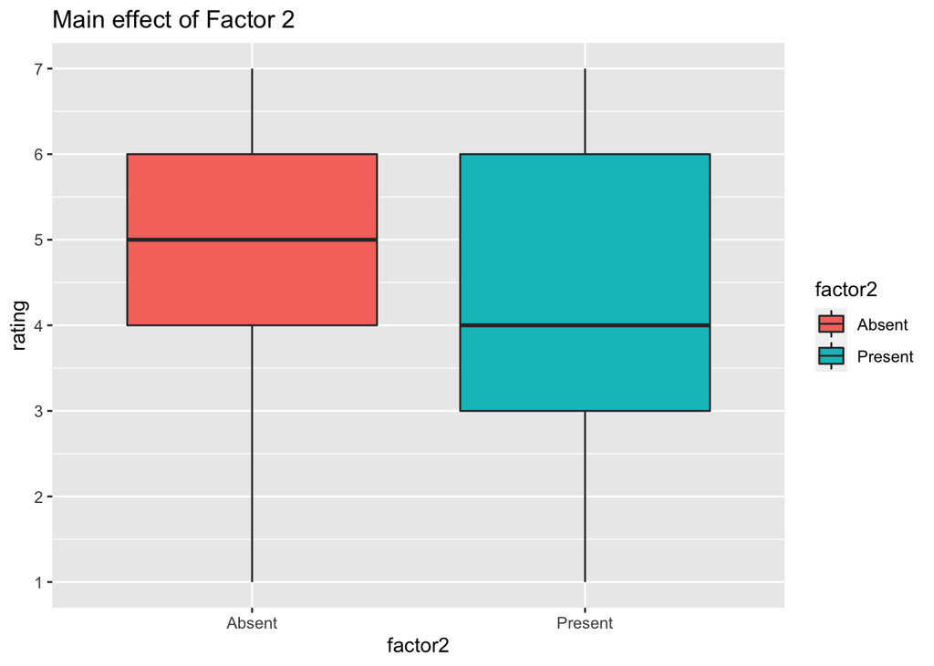

```r
ggplot(dataOrd, aes(x=factor2,y=rating)) + geom_boxplot(aes(fill=factor2)) + scale_y_continuous(breaks=c(1:7)) + ggtitle("Main effect of Factor 2")
```

However, we have seen in the interaction plot that the influence of *Factor 2* appears to be larger within the `Treatment` condition of *Factor 1*, so we might anticipate there being an interaction between the two main effects. We should conduct ordinal regression to see if this is the case.

# Ordinal regressions

When we summarise a **linear mixed effect model** of this rating data, this is what we get.

```r
lmer.rate.max <- lmer(rating ~ factor1*factor2 + (1|subject)+(1|item),data=dataOrd, REML=FALSE)
summary(lmer.rate.max)
```

```
## Linear mixed model fit by maximum likelihood  ['lmerMod']
## Formula: rating ~ factor1 * factor2 + (1 | subject) + (1 | item)
##    Data: dataOrd
##
##      AIC      BIC   logLik deviance df.resid
##   2892.6   2926.7  -1439.3   2878.6      953
##
## Scaled residuals:
##     Min      1Q  Median      3Q     Max
## -3.4690 -0.8577 -0.0005  0.8743  3.6434
##
## Random effects:
##  Groups   Name        Variance Std.Dev.
##  subject  (Intercept) 0.071283 0.26699
##  item     (Intercept) 0.001825 0.04272
##  Residual             1.128253 1.06219
## Number of obs: 960, groups:  subject, 40; item, 24
##
## Fixed effects:
##                                 Estimate Std. Error t value
## (Intercept)                      6.02083    0.08099  74.342
## factor1Treatment                -1.65833    0.09696 -17.102
## factor2Present                  -0.07083    0.09696  -0.731
## factor1Treatment:factor2Present -1.65417    0.13713 -12.063
##
## Correlation of Fixed Effects:
##             (Intr) fctr1T fctr2P
## fctr1Trtmnt -0.599
## factr2Prsnt -0.599  0.500
## fctr1Trt:2P  0.423 -0.707 -0.707
```

As in typical LMERs that one might produce using `lme4`, we can see the types of output, but it’s not looking good for *Factor 2*. We’re presented with various residuals and a summary of the random effects (which are important but I will skip for now). If we conducted a proper comparison of nested models with this dataset, we would get singular fits for each of the depleted models, but we would see that *Factor 2* does appear to have a significant contribution. But, in any case, let’s see what happens when we analyze it with a CLMM instead of LMER.

The following model is a **cumulative link mixed model** (CLMM), which operates in a very similar way to a linear mixed effect model on the surface, but takes into account the possibility that each level of the rating scale could be a different size or distance from its neighbors.

```r
clmm.max <- clmm(as.factor(rating) ~ factor1*factor2 + (1|subject)+(1|item),data=dataOrd)
summary(clmm.max)
```

```
## Cumulative Link Mixed Model fitted with the Laplace approximation
##
## formula: as.factor(rating) ~ factor1 * factor2 + (1 | subject) + (1 |
##     item)
## data:    dataOrd
##
##  link  threshold nobs logLik   AIC     niter      max.grad cond.H
##  logit flexible  960  -1377.05 2776.10 1269(3796) 9.11e-04 6.4e+01
##
## Random effects:
##  Groups  Name        Variance Std.Dev.
##  subject (Intercept) 0.17920  0.4233
##  item    (Intercept) 0.01514  0.1230
## Number of groups:  subject 40,  item 24
##
## Coefficients:
##                                 Estimate Std. Error z value Pr(>|z|)
## factor1Treatment                 -2.7711     0.1974 -14.040   <2e-16 ***
## factor2Present                   -0.1735     0.1672  -1.038    0.299
## factor1Treatment:factor2Present  -2.3701     0.2564  -9.243   <2e-16 ***
## ---
## Signif. codes:  0 '***' 0.001 '**' 0.01 '*' 0.05 '.' 0.1 ' ' 1
##
## Threshold coefficients:
##     Estimate Std. Error z value
## 1|2  -6.7035     0.2714 -24.703
## 2|3  -5.4889     0.2400 -22.867
## 3|4  -4.1191     0.2131 -19.332
## 4|5  -2.6917     0.1826 -14.745
## 5|6  -0.9258     0.1480  -6.254
## 6|7   0.5231     0.1458   3.588
```

You can see this in the section labeled `Threshold coefficients`, which shows the boundary estimates for each of the ordinal levels. (Note: you could probably plot these, too, just as I plot the estimates later on, but I won’t do that here.)

Just like you might with a LMER, you can do a nested model comparison to determine the contribution of each main effect and their interaction.

```r
clmm.int <- clmm(as.factor(rating) ~ factor1+factor2 + (1|subject)+(1|item),data=dataOrd)
clmm.one <- clmm(as.factor(rating) ~ factor2 + (1|subject)+(1|item),data=dataOrd)
clmm.two <- clmm(as.factor(rating) ~ factor1 + (1|subject)+(1|item),data=dataOrd)
```

First, by removing the interaction effect and comparing the depleted model to the maximal model, we find that the interaction contributes significantly to the overall model fit. This is expected, since we could visually detect something that looks like an interaction.

```r
anova(clmm.max,clmm.int)
```

```
## Likelihood ratio tests of cumulative link models:
##
##          formula:
## clmm.int as.factor(rating) ~ factor1 + factor2 + (1 | subject) + (1 | item)
## clmm.max as.factor(rating) ~ factor1 * factor2 + (1 | subject) + (1 | item)
##          link: threshold:
## clmm.int logit flexible
## clmm.max logit flexible
##
##          no.par    AIC  logLik LR.stat df Pr(>Chisq)
## clmm.int     10 2863.5 -1421.8
## clmm.max     11 2776.1 -1377.0  89.439  1  < 2.2e-16 ***
## ---
## Signif. codes:  0 '***' 0.001 '**' 0.01 '*' 0.05 '.' 0.1 ' ' 1
```

Next, we can look for the main effect of *Factor 1*. Note, however, that we compared this depleted model not to the maximal model but to the model with the interaction removed. This is because we should not check for a main effect by removing the main effect of one factor *while also comparing it to the model with both the main effect and interaction*. That would be counting the main effect twice, effectively. Technically, it is possible to do so, but the degrees of freedom with be 2. This is less informative because it includes two types of effects in the one model comparison.

```r
anova(clmm.int,clmm.one)
```

```
## Likelihood ratio tests of cumulative link models:
##
##          formula:
## clmm.one as.factor(rating) ~ factor2 + (1 | subject) + (1 | item)
## clmm.int as.factor(rating) ~ factor1 + factor2 + (1 | subject) + (1 | item)
##          link: threshold:
## clmm.one logit flexible
## clmm.int logit flexible
##
##          no.par    AIC  logLik LR.stat df Pr(>Chisq)
## clmm.one      9 3536.0 -1759.0
## clmm.int     10 2863.5 -1421.8  674.43  1  < 2.2e-16 ***
## ---
## Signif. codes:  0 '***' 0.001 '**' 0.01 '*' 0.05 '.' 0.1 ' ' 1
```

As expected, *Factor 1* contributes significantly to the model’s fit. But, if you look below, you will see that *Factor 2* also contributes significantly (although the Likelihood Ratio statistic is smaller for *Factor 2* than *Factor 1*).

```r
anova(clmm.int,clmm.two)
```

```
## Likelihood ratio tests of cumulative link models:
##
##          formula:
## clmm.two as.factor(rating) ~ factor1 + (1 | subject) + (1 | item)
## clmm.int as.factor(rating) ~ factor1 + factor2 + (1 | subject) + (1 | item)
##          link: threshold:
## clmm.two logit flexible
## clmm.int logit flexible
##
##          no.par    AIC  logLik LR.stat df Pr(>Chisq)
## clmm.two      9 2970.1 -1476.0
## clmm.int     10 2863.5 -1421.8  108.53  1  < 2.2e-16 ***
## ---
## Signif. codes:  0 '***' 0.001 '**' 0.01 '*' 0.05 '.' 0.1 ' ' 1
```

That solves our problem of the graphs! But maybe you’re not convinced. After all, the box and whisker plot for *Factor 2* aren’t very different…

The problem here is that box plots assume your data are continuous. This is why the y-axis is continuous and why the boxes are filled in even between the discrete numbers on the y-axis. But ordinal data isn’t continuous. There is a better way to visualise it, but it takes a little explanation:

# Visualising the ratings

If we visualise the ratings as probabilities, we can see subtle differences that aren’t visible in box plots or bar charts. The x-axis is the value of $\beta$, or the estimate of the coefficients (with the baseline set to 0). This means that if two conditions are very similar in terms of how participants used the ordinal scale to rate these stimuli, they will appear close together on the x-axis. The y-axis is the probability with which participants used each level of the scale, from 0 (extremely unlikely) to 1 (extremely likely). Crucially, this allows us to visualise how different levels vary within a condition, as well as between, using probability curves.

In this graph below, we can see the probability curves for each of the seven ratings. In particular, we can now see that the *Baseline+Present* condition and the *Baseline+Absent* condition are not rated in precisely the same manner: *Baseline+Absent* is more likely to receive a rating of 7 and less like to receive a rating of 5 than *Baseline+Present*.

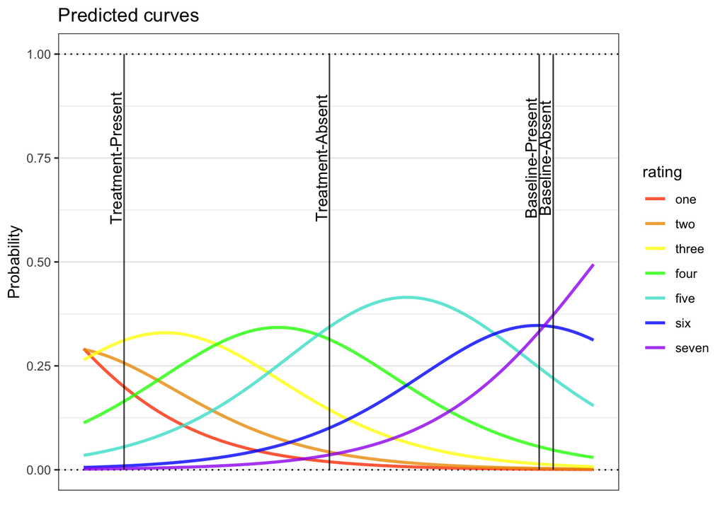

```r
# Script written by Lauren M Ackerman
# 26 February 2019
# Contact: l.m.ackerman AT gmail DOT com
# Adapted from Jalal Al-Tamimi

clmm.graph <- clmm(as.factor(rating) ~ interaction(factor1,factor2) +
                   (1|subject) +
                   (1|item),
                 data=dataOrd) # ordinal regression with INTERACTION BUILT INTO MAIN EFFECT
vlines <- c(0, # intercept, 0 = Baseline.Absent
            clmm.graph$beta[[1]], # interaction(factor1, factor2) = Treatment.Absent
            clmm.graph$beta[[2]], # interaction(factor1, factor2) = Baseline.Present
            clmm.graph$beta[[3]]) # interaction(factor1, factor2) = Treatment.Present
xaxis <- seq(min(vlines-.5), max(vlines+.5), length.out = 100) # create 100 steps
yaxis <- rep(c(0,1),50) # fill in 0s and 1s for y-axis
colors <- c("one" = "orangered",
            "two" = "orange2",
            "three" = "yellow",
            "four" = "green",
            "five" = "turquoise",
            "six" = "blue",
            "seven" = "purple") # establish the colour-rating level correspondence
tibble(xaxis,yaxis) %>% # baseline tibble for plot dimensions
  mutate(one=  plogis(clmm.graph$Theta[1] - xaxis), # add column for rating levels (must be adapted for larger scales)
         two=  plogis(clmm.graph$Theta[2] - xaxis) - plogis(clmm.graph$Theta[1] - xaxis),
         three=plogis(clmm.graph$Theta[3] - xaxis) - plogis(clmm.graph$Theta[2] - xaxis),
         four= plogis(clmm.graph$Theta[4] - xaxis) - plogis(clmm.graph$Theta[3] - xaxis),
         five= plogis(clmm.graph$Theta[5] - xaxis) - plogis(clmm.graph$Theta[4] - xaxis),
         six=  plogis(clmm.graph$Theta[6] - xaxis) - plogis(clmm.graph$Theta[5] - xaxis),
         seven=1 - (plogis(clmm.graph$Theta[6] - xaxis))) %>%
  gather(rating,probability,3:9) %>% # make long data (change right-hand number to suit the ordinal levels)
  mutate(rating=factor(rating,levels=c("one","two","three","four","five","six","seven"))) %>% # make factor and relevel
  ggplot(aes(x=xaxis,y=yaxis)) + # set up ggplot
  geom_hline(yintercept=0,lty="dotted") + # add lower horizontal line
  geom_hline(yintercept=1,lty="dotted") + # add upper horizontal line
  geom_line(aes(y=probability,colour=rating),lwd=1,alpha=.8) + # add predicted curves
  annotate("segment", # type of annotation = line segments
           x=vlines, y=0, xend=vlines, yend=1, # add estimates
           lty="solid", alpha=.75) + # visual properties of vertical lines
  annotate("text", # type of annotation = text
           x=vlines,y=.75, # location of labels
           label=c("Baseline-Absent",
                   "Treatment-Absent",
                   "Baseline-Present",
                   "Treatment-Present"), # label names aligned with vlines[1:4]
           angle=90,vjust=-0.2) + # visual properties of text labels
  scale_x_continuous(breaks=c(min(xaxis-.5),max(xaxis+.5))) + # expand x axis horizontally
  scale_y_continuous(breaks=c(0,.25,.5,.75,1)) + # expand y axis with consistent breaks
  ylab("Probability") + xlab("") + ggtitle("Predicted curves") + # label plot properties
  scale_colour_manual(values = colors) + # apply colours manually
  theme_bw() # improve visibility with white background
```

However, they are still very similar in terms of their mean rating (which is why they are grouped so closely). In some cases, when this difference ends up being significant, it will not be visible in a box plot but will be visible in this sort of probability curve plot.

One could also use this method to visualise the main effect of Factor 2, in order to get an idea of whether its two levels really are similar, or whether they just have similar median values (which is what the box plot shows us).

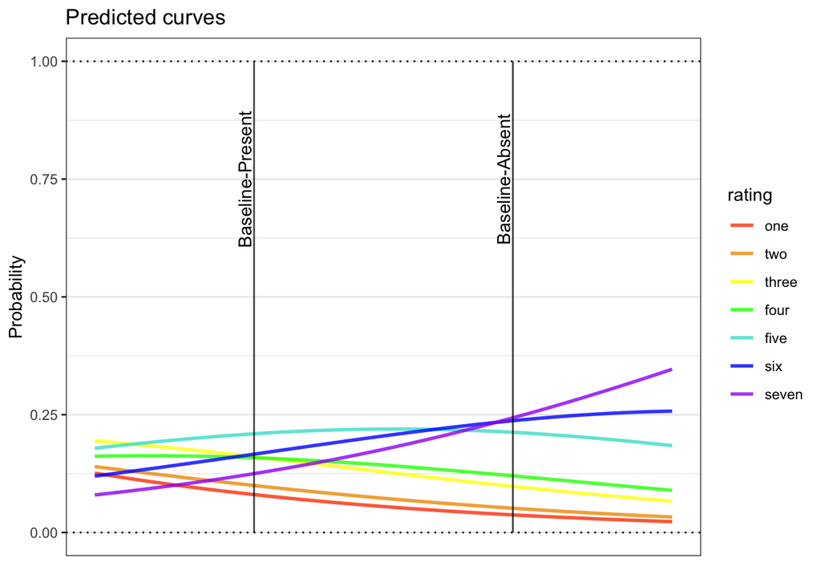

```r
clmm.graph <- clmm(as.factor(rating) ~ factor2 +
                   (1|subject) +
                   (1|item),
                 data=dataOrd) # ordinal regression with ONLY FACTOR 2

vlines <- c(0, # intercept, 0 = Absent
            clmm.graph$beta[[1]]) # interaction(factor1, factor2) = Present
xaxis <- seq(min(vlines-.5), max(vlines+.5), length.out = 100) # create 100 steps
yaxis <- rep(c(0,1),50) # fill in 0s and 1s for y-axis
colors <- c("one" = "orangered",
            "two" = "orange2",
            "three" = "yellow",
            "four" = "green",
            "five" = "turquoise",
            "six" = "blue",
            "seven" = "purple") # establish the colour-rating level correspondence
tibble(xaxis,yaxis) %>% # baseline tibble for plot dimensions
  mutate(one=  plogis(clmm.graph$Theta[1] - xaxis), # add column for rating levels (must be adapted for larger scales)
         two=  plogis(clmm.graph$Theta[2] - xaxis) - plogis(clmm.graph$Theta[1] - xaxis),
         three=plogis(clmm.graph$Theta[3] - xaxis) - plogis(clmm.graph$Theta[2] - xaxis),
         four= plogis(clmm.graph$Theta[4] - xaxis) - plogis(clmm.graph$Theta[3] - xaxis),
         five= plogis(clmm.graph$Theta[5] - xaxis) - plogis(clmm.graph$Theta[4] - xaxis),
         six=  plogis(clmm.graph$Theta[6] - xaxis) - plogis(clmm.graph$Theta[5] - xaxis),
         seven=1 - (plogis(clmm.graph$Theta[6] - xaxis))) %>%
  gather(rating,probability,3:9) %>% # make long data (change right-hand number to suit the ordinal levels)
  mutate(rating=factor(rating,levels=c("one","two","three","four","five","six","seven"))) %>% # make factor and relevel
  ggplot(aes(x=xaxis,y=yaxis)) + # set up ggplot
  geom_hline(yintercept=0,lty="dotted") + # add lower horizontal line
  geom_hline(yintercept=1,lty="dotted") + # add upper horizontal line
  geom_line(aes(y=probability,colour=rating),lwd=1,alpha=.8) + # add predicted curves
  annotate("segment", # type of annotation = line segments
           x=vlines, y=0, xend=vlines, yend=1, # add estimates
           lty="solid", alpha=.75) + # visual properties of vertical lines
  annotate("text", # type of annotation = text
           x=vlines,y=.75, # location of labels
           label=c("Baseline-Absent",
                   "Baseline-Present"), # label names aligned with vlines[1:4]
           angle=90,vjust=-0.2) + # visual properties of text labels
  scale_x_continuous(breaks=c(min(xaxis-.5),max(xaxis+.5))) + # expand x axis horizontally
  scale_y_continuous(breaks=c(0,.25,.5,.75,1)) + # expand y axis with consistent breaks
  ylab("Probability") + xlab("") + ggtitle("Predicted curves") + # label plot properties
  scale_colour_manual(values = colors) + # apply colours manually
  theme_bw() # improve visibility with white background
```

This is an extremely informative, if somewhat boring-looking graph. In the box plot, it was hard to tell whether these two groups different because their interquartile ranges were so similar. Here, we get a clearer view of why they do indeed differ. In the *Baseline+Present* condition, ratings of seven (and to a lesser extent six) are much less likely than in the *Baseline+Absent* condition. The inverse is true for ratings of one and two (and to a lesser extent, three and four). Ratings of five appear to be approximately equally likely for both.

## Some visualisations under construction

I have wondered whether it is possible to visualise the variable “sizes” of each of the levels of the ordinal scale. This is an attempt to plot them to visualise how they vary, including standard error confidence intervals. If you have suggestions for improvements, amendments, or uses, please email me at `lauren` [dot] `ackerman` [at] `ncl` [dot] `ac` [dot] `uk`.

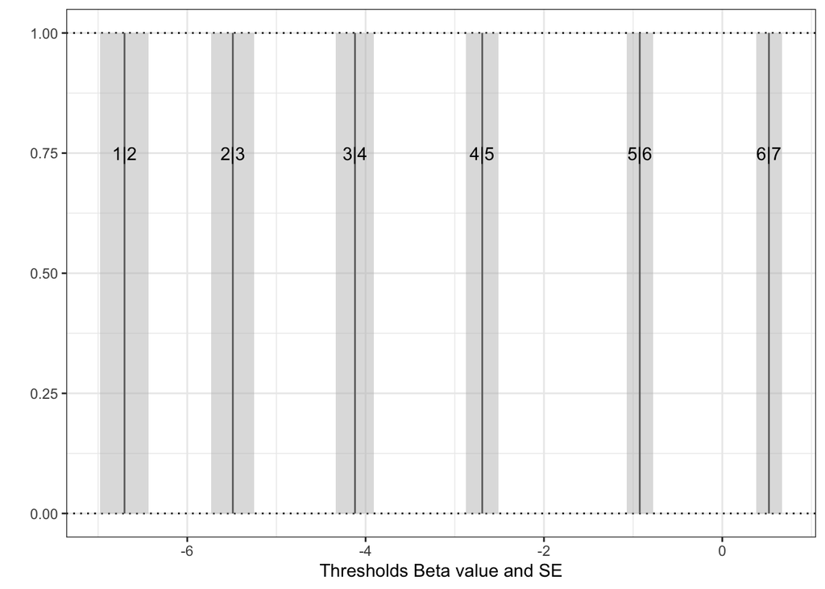

```r
clmm.graph <- clmm(as.factor(rating) ~ interaction(factor1,factor2) +
                   (1|subject) +
                   (1|item),
                 data=dataOrd) # ordinal regression with INTERACTION BUILT INTO MAIN EFFECT
levellines <- c(summary(clmm.max)$coefficient[,1][[1]],
                summary(clmm.max)$coefficient[,1][[2]],
                summary(clmm.max)$coefficient[,1][[3]],
                summary(clmm.max)$coefficient[,1][[4]],
                summary(clmm.max)$coefficient[,1][[5]],
                summary(clmm.max)$coefficient[,1][[6]])
levellinesSE <- c(summary(clmm.max)$coefficient[,2][[1]],
                  summary(clmm.max)$coefficient[,2][[2]],
                  summary(clmm.max)$coefficient[,2][[3]],
                  summary(clmm.max)$coefficient[,2][[4]],
                  summary(clmm.max)$coefficient[,2][[5]],
                  summary(clmm.max)$coefficient[,2][[6]])

tibble(xaxis,yaxis) %>% # baseline tibble for plot dimensions
  mutate(one=  plogis(clmm.graph$Theta[1] - xaxis), # add column for rating levels (must be adapted for larger scales)
         two=  plogis(clmm.graph$Theta[2] - xaxis) - plogis(clmm.graph$Theta[1] - xaxis),
         three=plogis(clmm.graph$Theta[3] - xaxis) - plogis(clmm.graph$Theta[2] - xaxis),
         four= plogis(clmm.graph$Theta[4] - xaxis) - plogis(clmm.graph$Theta[3] - xaxis),
         five= plogis(clmm.graph$Theta[5] - xaxis) - plogis(clmm.graph$Theta[4] - xaxis),
         six=  plogis(clmm.graph$Theta[6] - xaxis) - plogis(clmm.graph$Theta[5] - xaxis),
         seven=1 - (plogis(clmm.graph$Theta[6] - xaxis))) %>%
  gather(rating,probability,3:9) %>% # make long data (change right-hand number to suit the ordinal levels)
  mutate(rating=factor(rating,levels=c("one","two","three","four","five","six","seven"))) %>% # make factor and relevel
  ggplot(aes(x=xaxis,y=yaxis)) + # set up ggplot
  geom_hline(yintercept=0,lty="dotted") + # add lower horizontal line
  geom_hline(yintercept=1,lty="dotted") + # add upper horizontal line
  #geom_line(aes(y=probability,colour=rating),lwd=1,alpha=.8) + # add predicted curves
  annotate("segment", # type of annotation = line segments
           x=levellines, y=0, xend=levellines, yend=1, # add estimates
           lty="solid") +
  annotate("rect", # type of annotation = rectangle
           xmin=levellines-levellinesSE, ymin=0, xmax=levellines+levellinesSE, ymax=1, # add estimates
           lty="dotted", alpha=.5,fill="grey") +
  annotate("text", # type of annotation = text
           x=levellines,y=.75, # location of labels
           label=c("1|2","2|3","3|4","4|5","5|6","6|7")) + # label names aligned with vlines[1:4]
  xlab("Thresholds Beta value and SE") +
  ylab("") +
  theme_bw()
```

One interesting insight this plot provides is that the lower levels of the ordinal scale are both smaller and more variable (or less certain).

I would like to be able to plot confidence intervals around the predicted curves. This is my attempt to do so:

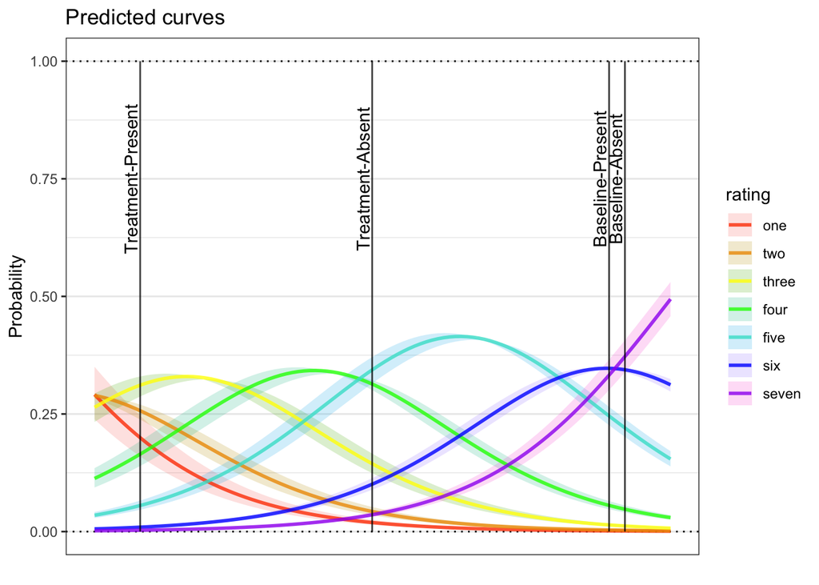

```r
clmm.graph <- clmm(as.factor(rating) ~ interaction(factor1,factor2) +
                   (1|subject) +
                   (1|item),
                 data=dataOrd) # ordinal regression with INTERACTION BUILT INTO MAIN EFFECT
vlines <- c(0, # intercept, 0 = Baseline.Absent
            clmm.graph$beta[[1]], # interaction(factor1, factor2) = Treatment.Absent
            clmm.graph$beta[[2]], # interaction(factor1, factor2) = Baseline.Present
            clmm.graph$beta[[3]]) # interaction(factor1, factor2) = Treatment.Present
xaxis <- seq(min(vlines-.5), max(vlines+.5), length.out = 100) # create 100 steps
yaxis <- rep(c(0,1),50) # fill in 0s and 1s for y-axis
colors <- c("one" = "orangered",
            "two" = "orange2",
            "three" = "yellow",
            "four" = "green",
            "five" = "turquoise",
            "six" = "blue",
            "seven" = "purple") # establish the colour-rating level correspondence
tibble(xaxis,yaxis) %>% # baseline tibble for plot dimensions
  mutate(one.base=  plogis(clmm.graph$Theta[1] - xaxis), # add column for rating levels (must be adapted for larger scales)
         two.base=  plogis(clmm.graph$Theta[2] - xaxis) -
                    plogis(clmm.graph$Theta[1] - xaxis),
         three.base=plogis(clmm.graph$Theta[3] - xaxis) -
                    plogis(clmm.graph$Theta[2] - xaxis),
         four.base= plogis(clmm.graph$Theta[4] - xaxis) -
                    plogis(clmm.graph$Theta[3] - xaxis),
         five.base= plogis(clmm.graph$Theta[5] - xaxis) -
                    plogis(clmm.graph$Theta[4] - xaxis),
         six.base=  plogis(clmm.graph$Theta[6] - xaxis) -
                    plogis(clmm.graph$Theta[5] - xaxis),
         seven.base=1 - (plogis(clmm.graph$Theta[6] - xaxis))) %>%
  mutate(one.add=  plogis(clmm.graph$Theta[1]+summary(clmm.max)$coefficient[,2][[1]] - xaxis), # add column for upper SE CI (must be adapted for larger scales)
         two.add=  plogis(clmm.graph$Theta[2]+summary(clmm.max)$coefficient[,2][[2]] - xaxis) -
                   plogis(clmm.graph$Theta[1]+summary(clmm.max)$coefficient[,2][[1]] - xaxis),
         three.add=plogis(clmm.graph$Theta[3]+summary(clmm.max)$coefficient[,2][[3]] - xaxis) -
                   plogis(clmm.graph$Theta[2]+summary(clmm.max)$coefficient[,2][[2]] - xaxis),
         four.add= plogis(clmm.graph$Theta[4]+summary(clmm.max)$coefficient[,2][[4]] - xaxis) -
                   plogis(clmm.graph$Theta[3]+summary(clmm.max)$coefficient[,2][[3]] - xaxis),
         five.add= plogis(clmm.graph$Theta[5]+summary(clmm.max)$coefficient[,2][[5]] - xaxis) -
                   plogis(clmm.graph$Theta[4]+summary(clmm.max)$coefficient[,2][[4]] - xaxis),
         six.add=  plogis(clmm.graph$Theta[6]+summary(clmm.max)$coefficient[,2][[6]] - xaxis) -
                   plogis(clmm.graph$Theta[5]+summary(clmm.max)$coefficient[,2][[5]] - xaxis),
         seven.add=1 - (plogis(clmm.graph$Theta[6]+summary(clmm.max)$coefficient[,2][[6]] - xaxis))) %>%
  mutate(one.sub=  plogis(clmm.graph$Theta[1]-summary(clmm.max)$coefficient[,2][[1]] - xaxis), # add column for lower SE CI (must be adapted for larger scales)
         two.sub=  plogis(clmm.graph$Theta[2]-summary(clmm.max)$coefficient[,2][[2]] - xaxis) -
                   plogis(clmm.graph$Theta[1]-summary(clmm.max)$coefficient[,2][[1]] - xaxis),
         three.sub=plogis(clmm.graph$Theta[3]-summary(clmm.max)$coefficient[,2][[3]] - xaxis) -
                   plogis(clmm.graph$Theta[2]-summary(clmm.max)$coefficient[,2][[2]] - xaxis),
         four.sub= plogis(clmm.graph$Theta[4]-summary(clmm.max)$coefficient[,2][[4]] - xaxis) -
                   plogis(clmm.graph$Theta[3]-summary(clmm.max)$coefficient[,2][[3]] - xaxis),
         five.sub= plogis(clmm.graph$Theta[5]-summary(clmm.max)$coefficient[,2][[5]] - xaxis) -
                   plogis(clmm.graph$Theta[4]-summary(clmm.max)$coefficient[,2][[4]] - xaxis),
         six.sub=  plogis(clmm.graph$Theta[6]-summary(clmm.max)$coefficient[,2][[6]] - xaxis) -
                   plogis(clmm.graph$Theta[5]-summary(clmm.max)$coefficient[,2][[5]] - xaxis),
         seven.sub=1 - (plogis(clmm.graph$Theta[6]-summary(clmm.max)$coefficient[,2][[6]] - xaxis))) %>%
  gather(level,probability,3:23) %>% # make long data (change right-hand number to suit the ordinal levels)
  separate(level,c("rating","type")) %>% # tidy values in "rating" column for next step
  spread(type,probability) %>% # spread so it's slightly wider data, keeping baseline and SE CI (upper and lower) values seperate
  mutate(rating=factor(rating,levels=c("one","two","three","four","five","six","seven"))) %>% # make factor and relevel
  ggplot(aes(x=xaxis,y=yaxis)) + # set up ggplot
  geom_hline(yintercept=0,lty="dotted") + # add lower horizontal line
  geom_hline(yintercept=1,lty="dotted") + # add upper horizontal line
  geom_ribbon(aes(ymin=sub,ymax=add,fill=rating),lwd=1,alpha=.2) + # add predicted curves confidence intervals *** NEEDS WORK **
  geom_line(aes(y=base,colour=rating),lwd=1,alpha=.8) + # add predicted curves
  annotate("segment", # type of annotation = line segments
           x=vlines, y=0, xend=vlines, yend=1, # add estimates
           lty="solid", alpha=.75) + # visual properties of vertical lines
  annotate("text", # type of annotation = text
           x=vlines,y=.75, # location of labels
           label=c("Baseline-Absent",
                   "Treatment-Absent",
                   "Baseline-Present",
                   "Treatment-Present"), # label names aligned with vlines[1:4]
           angle=90,vjust=-0.2) + # visual properties of text labels
  scale_x_continuous(breaks=c(min(xaxis-.5),max(xaxis+.5))) + # expand x axis horizontally
  scale_y_continuous(breaks=c(0,.25,.5,.75,1)) + # expand y axis with consistent breaks
  ylab("Probability") + xlab("") + ggtitle("Predicted curves") + # label plot properties
  scale_colour_manual(values = colors) + # apply colours manually
  theme_bw() # improve visibility with white background
```

I think this is neither necessarily the correct nor the easiest way to do this, and I cannot recommend using this code to produce professional visualisations of the predicted curves’ standard error confidence intervals. I am providing this code so that others may build on it and feed back to me so that I can update it and complete the tutorial properly. ¡Buena suerte!

# Summary

Ordinal regressions are more appropriate for ordinal data than linear regressions are for a number of reasons. You don’t need to transform your data, you can account for the levels not being “sized” linearly and you can account for subjects treating the individual levels differently than each other.

If you analyse an ordinal regression, however, it is also important to visualise your data in an appropriate way. Box plots (and similarly, violin plots) are not optimal because they assume continuous data. Ordinal data is discrete *and* its levels are independent, so it makes more sense to visualise the probability of each level being selected, rather than the mean or median values for each condition.